# Data science project - Suicidial attacks

Mr.Jakob Alderson & Mr.Tal Bracha

2022-07-25

## Intro - why its importent?

The main reasons suicide attacks are particularly important to research are:

*Suicide attacks are five times more lethal than ordinary attacks.

*In the last 5 years suicide attacks have become more and more common, and have been used in 40% of all conflicts in comparison to 4% in the 80s.

*Suicide attacks have become a popular combat tactic among militant groups, especially when combating stronger military forces.

*Due to their shocking nature they amplify militant group’s propaganda efforts.

*Suicide attacks also increase recruitment by demonstrating the group’s ideological commitment.

## Research question

What is the connection between human capital and the lethality of suicidal attacks?

## litetature 1 - Human Capital and the Productivity of Suicide Bombers

Benmelech’s and Berrebi’s article (2017) provides the first detailed empirical analysis of the relationship between suicide bomber’s characteristics and their performance in a suicide bombing attacks, The conclusion was that Palestinian terror organizations match older and more-educated suicide bombers to more important Israeli targets, another conclusion was that older and more-educated suicide bombers kill more people in their suicide attacks when assigned to important targets. Furthermore, older and more-educated suicide bombers are less likely to fail or to be caught when they attack.

This paper also contributes to the debate on the relation between education, poverty, and terrorism. While suicide bombers are on average more educated than the general Palestinian population, their estimate of a higher education among suicide bombers is three times lower than the figures reported by Berrebi (2003) and Krueger and Maleckova (2003).

## litetature 2 - What’s Special about Female Suicide Terrorism?

O’Rourke’s article (2009) analyzes the interaction between the motivations of individual attackers and terrorist group strategies. To do so it combines a quantitative analysis of all known suicide terrorist attacks between 1981 and July 2008 with a strategic account of why terrorist organizations employ female suicide terrorism and case studies of individual female attackers. The author advances five main claims:

1)She reveals the superior effectiveness of female suicide terrorism from the perspective of the groups that employ women.

2)She explains that terrorist groups increasingly enlist women as suicide attackers because of their higher effectiveness.

3)She demonstrates that terrorist groups adapt their discourse, catering to the specific individual motives of potential female suicide attackers to recruit them.

4)She shows that female attackers are driven by the same general motives and circumstances that drive men.

5)She concludes that, unless target states adapt their defensive strategies, we should expect an increase in female suicide terrorism.

## Suicidal attacks global or middle eastern problem?

```r
points = read.csv("attacks.csv")
points = points[!is.na(points$latitude), ]
points = points[!is.na(points$longitude), ]
```

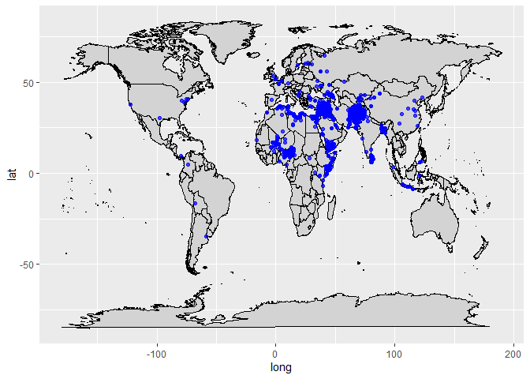

```r
world <- map_data("world")
   ggplot() +
     geom_map(
       data = world, map = world,
       aes(long, lat, map_id = region),
       color = "black", fill = "lightgray", size = 0.1
     ) +
     geom_point(
       data = points,
       aes(longitude, latitude), color = "blue",
       alpha = 0.7
     )
```

Points density:

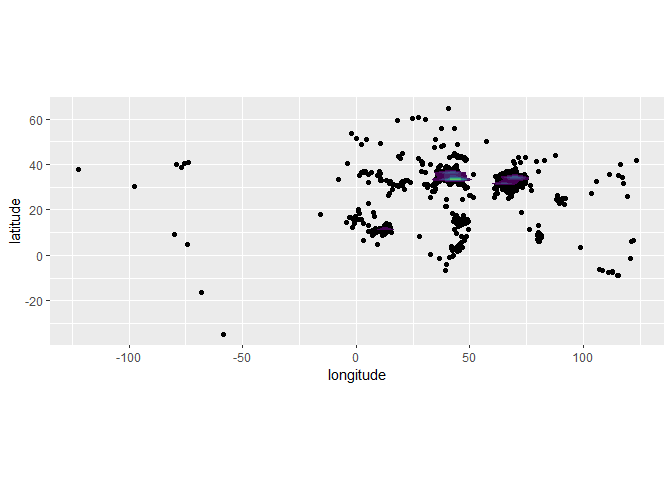

```r
ggplot(points, aes(x = longitude, y = latitude)) +
     geom_point() +
     coord_equal() +
     xlab('longitude') +
     ylab('latitude') +
     stat_density2d(aes(fill = ..level..), alpha = 100,
                    geom = "polygon", data = points) +
     scale_fill_viridis_c() +
     theme(legend.position = 'none')
```

The middle east is the brightest

## Data Cleaning and Normaliry transformation:

Before cleaning:

```r
attacks = read.csv("attacks.csv")
head(as_tibble(attacks))
```

```
## # A tibble: 6 × 94
##   data_release    event_id summary        status ct_sources event_date date_year
##   <chr>              <int> <chr>          <chr>       <int> <chr>          <int>
## 1 02-Oct-20    -2146485992 6/23/2015: In… Confi…          2 6/23/2015       2015
## 2 02-Oct-20    -2146060571 1/14/2017: In… Possi…          3 1/14/2017       2017
## 3 02-Oct-20    -2145067987 10/15/2004: I… Confi…          4 10/15/2004      2004
## 4 02-Oct-20    -2145029986 7/20/2017: In… Possi…          5 7/20/2017       2017
## 5 02-Oct-20    -2143985988 10/3/2012: In… Confi…          4 10/3/2012       2012
## 6 02-Oct-20    -2143771747 10/23/2010: I… Confi…          3 10/23/2010      2010
## # … with 87 more variables: date_month <int>, date_day <int>,
## #   wounded_low <int>, wounded_high <int>, killed_low <int>, killed_high <int>,
## #   killed_low_civilian <int>, killed_high_civilian <int>,
## #   killed_low_political <int>, killed_high_political <int>,
## #   killed_low_security <int>, killed_high_security <int>, ct_belt_bomb <int>,
## #   ct_truck_bomb <int>, ct_car_bomb <int>, ct_weapon_oth <int>,
## #   ct_weapon_unk <int>, weapon_id <int>, weapon_txt <chr>, …
```

After some data cleaning:

```r
attacks = as_tibble(attacks) %>%
  select(event_id,wounded_low,wounded_high,killed_low,killed_high,admin0_txt,date_year) %>%
  filter(wounded_low >= 0) %>%
  filter(wounded_high >= 0) %>%
  filter(killed_low >= 0) %>%
  filter(killed_high >= 0) %>%
  mutate(wounded_average = ceiling(((wounded_low + wounded_high)/2) )) %>%
  mutate(killed_average = ceiling(((killed_low + killed_high)/2) )) %>%
  mutate(casualties = wounded_average + killed_average) %>%
  filter(casualties < 500) %>%
  rename( country = admin0_txt) %>%
select(event_id,wounded_average,killed_average,casualties,country,date_year)
head(attacks)
```

```
## # A tibble: 6 × 6
##      event_id wounded_average killed_average casualties country     date_year
##         <int>           <dbl>          <dbl>      <dbl> <chr>           <int>
## 1 -2146485992               8              5         13 Syria            2015
## 2 -2146060571               0             40         40 Syria            2017
## 3 -2145067987              13              6         19 Iraq             2004
## 4 -2145029986               2              0          2 Afghanistan      2017
## 5 -2143985988             110             36        146 Syria            2012
## 6 -2143771747               7              1          8 Russia           2010
```

## Normality visualtization:

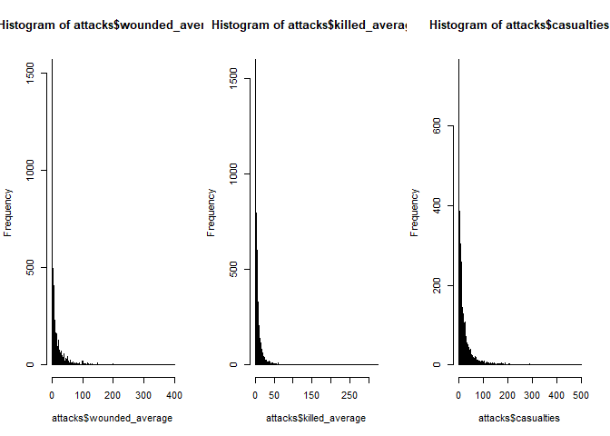

```r
par(mfrow = c(1,3))
hist(attacks$wounded_average, breaks = length(attacks$wounded_average))
hist(attacks$killed_average, breaks = length(attacks$killed_average))
hist(attacks$casualties, breaks = length(attacks$casualties))
```

The data is in Poisson distribution, we have a massive positive right skew.

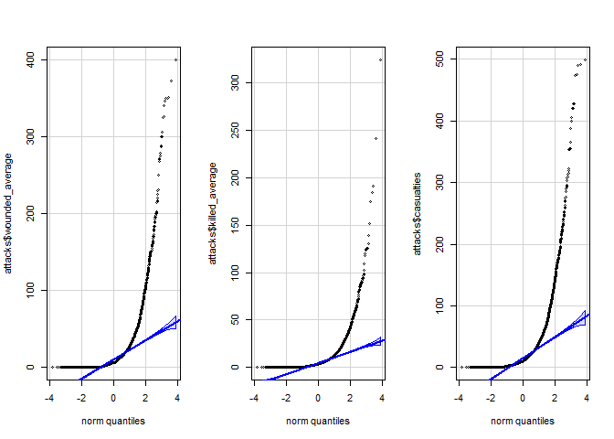

```r
par(mfrow = c(1,3))
qqPlot(attacks$wounded_average, id= FALSE)
qqPlot(attacks$killed_average, id= FALSE)
qqPlot(attacks$casualties, id= FALSE)
```

## Square root data transformation:

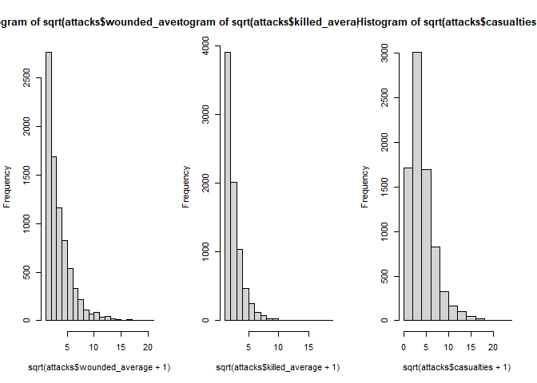

```r
par(mfrow = c(1,3))
hist(sqrt(attacks$wounded_average + 1 ))
hist(sqrt(attacks$killed_average + 1 ))
hist(sqrt(attacks$casualties + 1))
```

## Log(10) data transformation:

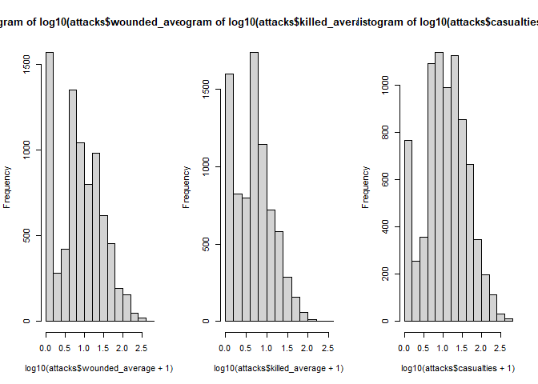

```r
par(mfrow = c(1,3))
hist(log10(attacks$wounded_average + 1 ))
hist(log10(attacks$killed_average + 1 ))
hist(log10(attacks$casualties + 1 ))
```

## Inverse data transformation:

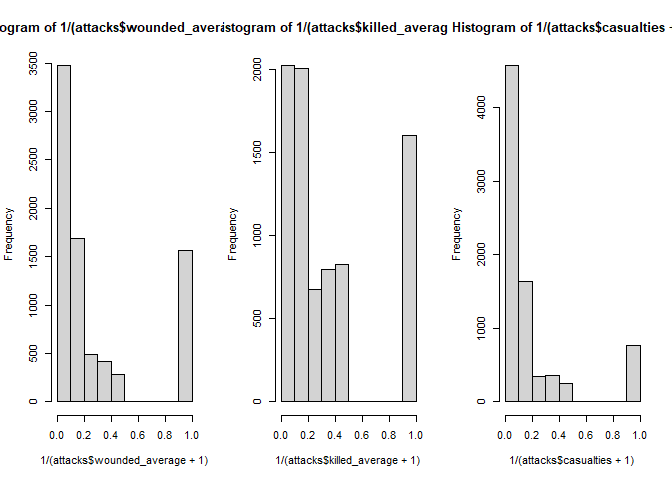

```r
par(mfrow = c(1,3))
hist(1/(attacks$wounded_average + 1 ))
hist(1/(attacks$killed_average + 1 ))
hist(1/(attacks$casualties + 1))
```

## log 10 looks like normal distribution, but what’s the problem?

```r
agostino.test(log10(attacks$casualties+1))
```

```
##
##  D'Agostino skewness test
##
## data:  log10(attacks$casualties + 1)
## skew = -0.1088, z = -3.9484, p-value = 7.866e-05
## alternative hypothesis: data have a skewness
```

## too many repetitions!

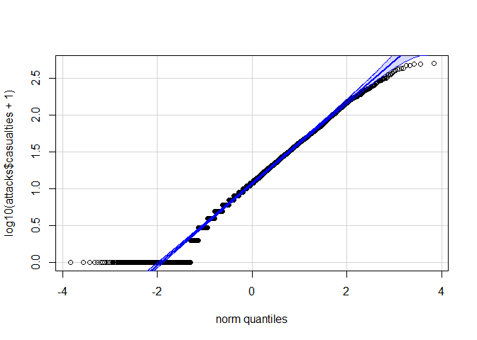

```r
qqPlot(log10(attacks$casualties+1),id= FALSE)
```

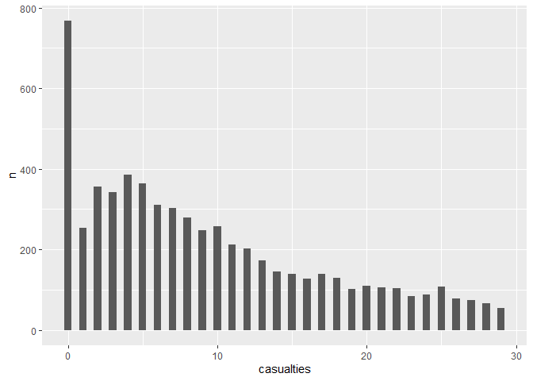

```r
attacks2 = attacks %>%
  count(casualties, sort = TRUE) %>%
  filter(casualties < 30)

      ggplot(data = attacks2, aes(x=casualties, y=n)) +
  geom_bar(stat="identity", width=0.5)
```

We did our best but you cant transform poisson distribution with low lambda

## Age and Suicidal Attacks correlation and regression

```r
attackers = read.csv("attackers.csv")
head( as_tibble(attackers) )
```

```
## # A tibble: 6 × 13
##   data_release    event_id attacker_id gender  birth_year age_time_death
##   <chr>              <int>       <int> <chr>        <int>          <int>
## 1 02-Oct-20    -2146485992  -274979578 Unknown         -1             -1
## 2 02-Oct-20    -2146060571 -1349440448 Unknown         -1             -1
## 3 02-Oct-20    -2146060571  1487611308 Unknown         -1             -1
## 4 02-Oct-20    -2145067987   663458966 Unknown         -1             -1
## 5 02-Oct-20    -2145029986  -163911859 Unknown         -1             -1
## 6 02-Oct-20    -2143985988  1406415357 Unknown         -1             -1
## # … with 7 more variables: birth_admin0_id <int>, birth_admin0_cow_id <int>,
## #   birth_admin1_id <int>, birth_city_id <int>, birth_admin0_txt <chr>,
## #   birth_admin1_txt <chr>, birth_city_txt <chr>
```

```r
attackers_new = attackers %>%
  as_tibble() %>%
  select(event_id,attacker_id,age_time_death,gender,birth_admin0_txt,) %>%
  rename(birth_city = birth_admin0_txt) %>%
  filter(age_time_death > 0) %>%
  filter(gender %in% c("Male" , "Female") )
  head(attackers_new)
```

```
## # A tibble: 6 × 5
##      event_id attacker_id age_time_death gender birth_city
##         <int>       <int>          <int> <chr>  <chr>
## 1 -2134654500  1845652330             26 Male   Palestine
## 2 -2123020174  -135992336             20 Male   Palestine
## 3 -2121629020   309934450             21 Male   Palestine
## 4 -2116822737   124071698             23 Male   Syria
## 5 -2105951685  1695931383             23 Male   Pakistan
## 6 -2101445564  1033915410             23 Male   Palestine
```

## Male correlation

```r
male_attackers = attackers_new %>%
filter(gender == "Male") %>%
inner_join(attacks, by =  "event_id") %>%
select(age_time_death,wounded_average,killed_average,casualties,gender,birth_city)
head(male_attackers)
```

```
## # A tibble: 6 × 6
##   age_time_death wounded_average killed_average casualties gender birth_city
##            <int>           <dbl>          <dbl>      <dbl> <chr>  <chr>
## 1             26              30              6         36 Male   Palestine
## 2             20              36              2         38 Male   Palestine
## 3             21               3              1          4 Male   Palestine
## 4             23              16              1         17 Male   Syria
## 5             23               3              3          6 Male   Pakistan
## 6             23              34              5         39 Male   Palestine
```

```r
res<-cor.test(male_attackers$age_time_death,male_attackers$wounded_average, method="kendall")
res$p.value
```

```
## [1] 0.05050414
```

```r
res2<-cor.test(male_attackers$age_time_death,male_attackers$killed_average, method="kendall")
res2$p.value
```

```
## [1] 0.4127307
```

```r
res3<-cor.test(male_attackers$age_time_death,male_attackers$casualties, method="kendall")
res3$p.value
```

```
## [1] 0.5481857
```

## Male regression

```r
res4= glm(casualties ~  age_time_death, data = male_attackers , family = "poisson"  )
summary(res4)
```

```
##
## Call:
## glm(formula = casualties ~ age_time_death, family = "poisson",
##     data = male_attackers)
##
## Deviance Residuals:
##     Min       1Q   Median       3Q      Max
## -10.934   -7.573   -4.578    1.364   38.895
##
## Coefficients:
##                 Estimate Std. Error z value Pr(>|z|)
## (Intercept)    3.5673878  0.0189076 188.675   <2e-16 ***
## age_time_death 0.0072674  0.0007494   9.698   <2e-16 ***
## ---
## Signif. codes:  0 '***' 0.001 '**' 0.01 '*' 0.05 '.' 0.1 ' ' 1
##
## (Dispersion parameter for poisson family taken to be 1)
##
##     Null deviance: 46604  on 673  degrees of freedom
## Residual deviance: 46514  on 672  degrees of freedom
## AIC: 49432
##
## Number of Fisher Scoring iterations: 6
```

## Female correlation

```r
female_attackers = attackers_new %>%
filter(gender == "Female") %>%
inner_join(attacks, by =  "event_id") %>%
select(age_time_death,wounded_average,killed_average,casualties,gender,birth_city)
head(female_attackers)
```

```
## # A tibble: 6 × 6
##   age_time_death wounded_average killed_average casualties gender birth_city
##            <int>           <dbl>          <dbl>      <dbl> <chr>  <chr>
## 1             26               0              1          1 Female Russia
## 2             18               9              0          9 Female Unknown
## 3             12               3              5          8 Female Unknown
## 4             16               2              2          4 Female Lebanon
## 5             19              54             60        114 Female Unknown
## 6             11              53             15         68 Female Unknown
```

```r
fes<-cor.test(female_attackers$age_time_death,female_attackers$wounded_average, method="kendall")
fes$p.value
```

```
## [1] 0.001992474
```

```r
fes2<-cor.test(female_attackers$age_time_death,female_attackers$killed_average, method="kendall")
fes2$p.value
```

```
## [1] 0.8391764
```

```r
fes3<-cor.test(female_attackers$age_time_death,female_attackers$casualties, method="kendall")
fes3$p.value
```

```
## [1] 0.3080308
```

## Female regression

```r
fes4= glm(killed_average ~  age_time_death, data = female_attackers , family = "poisson"    )
summary(fes4)
```

```
##
## Call:
## glm(formula = killed_average ~ age_time_death, family = "poisson",
##     data = female_attackers)
##
## Deviance Residuals:
##    Min      1Q  Median      3Q     Max
## -5.288  -3.755  -1.664   1.312  10.914
##
## Coefficients:
##                Estimate Std. Error z value Pr(>|z|)
## (Intercept)    2.073634   0.064229  32.285  < 2e-16 ***
## age_time_death 0.009895   0.002984   3.316 0.000912 ***
## ---
## Signif. codes:  0 '***' 0.001 '**' 0.01 '*' 0.05 '.' 0.1 ' ' 1
##
## (Dispersion parameter for poisson family taken to be 1)
##
##     Null deviance: 2182.6  on 154  degrees of freedom
## Residual deviance: 2172.2  on 153  degrees of freedom
## AIC: 2636.2
##
## Number of Fisher Scoring iterations: 6
```

## Male vs Female - wounded average

```r
both_gender1 = bind_rows(male_attackers,female_attackers) %>%
  select(gender,wounded_average )
test <- wilcox.test(both_gender1$wounded_average ~ both_gender1$gender)
test$p.value
```

```
## [1] 0.1668247
```

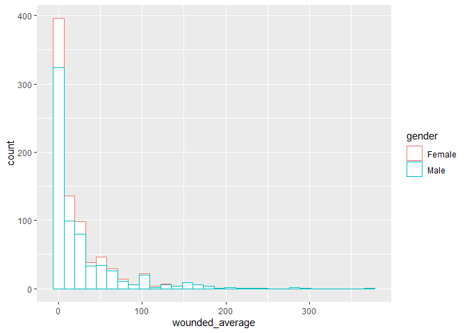

```r
ggplot(both_gender1, aes(x= wounded_average, color=gender)) +
  geom_histogram(fill="white")
```

## Male vs Female - killed average

```r
both_gender2 = bind_rows(male_attackers,female_attackers) %>%
  select(gender,killed_average )
test2 <- wilcox.test(both_gender2$killed_average ~ both_gender2$gender)
test2$p.value
```

```
## [1] 0.5283723
```

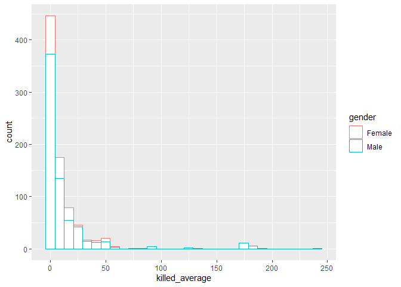

```r
ggplot(both_gender2, aes(x= killed_average, color=gender)) +
  geom_histogram(fill="white")
```

## Male vs Female - Casualties

```r
both_gender3 = bind_rows(male_attackers,female_attackers) %>%
  select(gender,casualties )
test3 <- wilcox.test(both_gender3$casualties ~ both_gender3$gender)
test3$p.value
```

```
## [1] 0.4057901
```

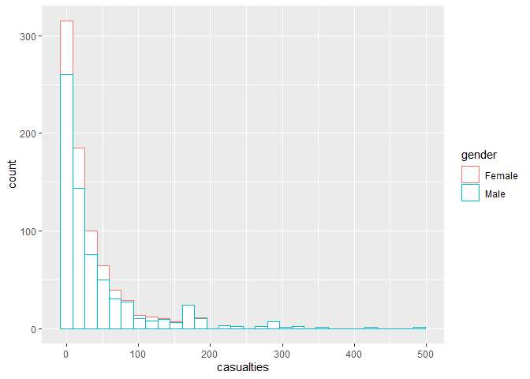

```r
ggplot(both_gender3, aes(x= casualties, color=gender)) +
  geom_histogram(fill="white")
```

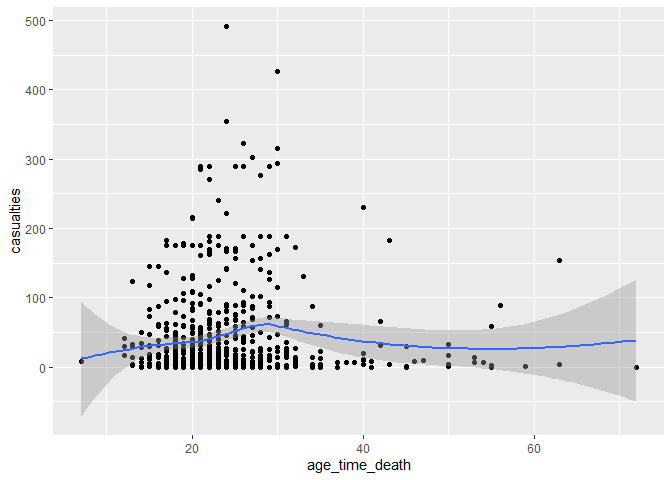

```r
ggplot(data = male_attackers) +
      geom_point(mapping = aes(x = age_time_death, y = casualties)) +
      geom_smooth(mapping = aes(x = age_time_death, y = casualties))
```

## compare other poeple

```r
options(dplyr.print_max = 1e9)
attackers_new %>%
  group_by(birth_city) %>%
  summarise(n = n()) %>%
  arrange(desc(n))
```

```
## # A tibble: 47 × 2
##    birth_city               n
##    <chr>                <int>
##  1 Unknown                227
##  2 Palestine              158
##  3 Sri Lanka              131
##  4 Russia                  47
##  5 Lebanon                 37
##  6 Pakistan                29
##  7 Saudi Arabia            23
##  8 Iraq                    21
##  9 Turkey                  20
## 10 Afghanistan             15
## 11 Syria                   12
## 12 Indonesia               11
```

[output cut: 35 more lines]

```r
library(tidyverse)
library(leaflet)

leaflet(data = points) %>%
  addTiles() %>%
  addMarkers(lat=points$latitude, lng=points$longitude, clusterOptions = markerClusterOptions(),
             popup= paste("<strong>Date: </strong>", points$date_day,"/",points$date_month,"/", points$date_year,
                          "<br><br><strong>Place: </strong>", points$city_txt,"-",points$admin0_txt,
                          "<br><strong>Killed_low_estimate: </strong>", points$killed_low,
                          "<br><strong>Killed_high_estimate: </strong>", points$killed_high,
                          "<br><strong>wounded_low_estimate: </strong>", points$wounded_low,
                          "<br><strong>wounded_high_estimate: </strong>", points$wounded_high,
                          "<br><strong>wepon: </strong>", points$weapon_txt


             ))
```

[interactive chart not shown]

```r
attacks_graph = attacks %>%
inner_join(attackers_new, by =  "event_id") %>%
select(event_id,date_year,gender,country)  %>%
add_count(date_year)  %>%
add_count(gender)
```

```
## Storing counts in `nn`, as `n` already present in input
## ℹ Use `name = "new_name"` to pick a new name.
```

```r
attacks_graph
```

```
## # A tibble: 829 × 6
##        event_id date_year gender country                  n    nn
##           <int>     <int> <chr>  <chr>                <int> <int>
##   1 -2134654500      2005 Male   Israel                  27   674
##   2 -2123020174      2002 Male   Israel                  53   674
##   3 -2121629020      2005 Male   Palestine               27   674
##   4 -2116822737      2009 Male   Iraq                    55   674
##   5 -2105951685      2009 Male   Pakistan                55   674
##   6 -2101445564      2002 Male   Israel                  53   674
##   7 -2100543043      1997 Male   Israel                  17   674
##   8 -2088282966      2010 Female Russia                  27   155
##   9 -2081651973      2002 Male   Israel                  53   674
##  10 -2075258081      1998 Female Turkey                  18   155
##  11 -2074450697      2010 Male   Russia                  27   674
##  12 -2071951000      2003 Male   Palestine               62   674
```

[output cut: 817 more lines]